# Exploratory Data Analysis

Adapted for [ForestGEO](https://twitter.com/ForestGEO?lang=en) from [R for Data Science](http://r4ds.had.co.nz/), by [Hadley Wickham](https://twitter.com/hadleywickham) and [Garrett Grolemund](https://twitter.com/StatGarrett)

Mauro Lepore

2017-08-03

# Introduction

This vignette literaly reproduces the section *Exploratory Data Analysis* in [R for Data Science](http://r4ds.had.co.nz/), by [Hadley Wickham](https://twitter.com/hadleywickham) and [Garrett Grolemund](https://twitter.com/StatGarrett), except that the examples and some text were changed to more strongly engage ecologysts from [ForestGEO](https://twitter.com/ForestGEO?lang=en).

You will learn how to explore your data systematically, using modern and powerful tools for visualization and transformation. An exploratory data analysis is an iterative process that aims to use data and some research questions to learn something that can help you refine those questions and move forward the learning spiral.

## Prerequisites

The data we will use was made public in 2012; it is from census 7 of the forest plot in Barro Colorado Island (hereafter referred to as BCI), in Panama. Those data are available in the data set *bci12full7* in the **[bci](https://forestgeo.github.io/bci/)** data package. Alternatively, you can use the data set *bci.full7*, in the file bci.full.Rdata31Aug2012.zip at DOI: https://doi.org/10.5479/data.bci.20130603. If you use the later data set, replace *bci12full7* by *bci.full7* everywhere in this vignette.

Most functions we will use are available in the **[tidyverse](http://tidyverse.org/)** package. If you are new to the **tidyverse**, you may feel a little frustrated at the beginning, but quickly your effort will pay-off. The tools in the **tidyverse** are powerful, relatively easy to use and consistent; so once you learn some, you will learn most other tools intuitively. To more completely learn how to do data science with the **tidyverse** read [R for Data Science](http://r4ds.had.co.nz/).

```r
library(bci)  # data from BCI (alternative: https://goo.gl/VKbcMz)
library(tidyverse)  # visualize and transform data (and more)
```

## Style

### Unequivocally identifying where functions come from

Frequently I refer to functions from a particular package as `package::fun()`. Although the prefix `package::` is unnecessary if you previously run `library(package)`, the prefix identifies unequivocally what package the function `fun()` comes from, and may help you to find that function if you need it (compare `?dplyr::filter` versus `?stats::filter`).

### The tidyverse style guide

I use [The tidyverse style guide](http://style.tidyverse.org/).

> Good coding style is like correct punctuation: you can manage without it, butitsuremakesthingseasiertoread.

–[The tidyverse style guide](http://style.tidyverse.org/index.html)

### Combining multiple operations with the pipe `%>%`

Often I combine multiple operations with the pipe `%>%` because it makes the code considerably more readable.

> [The pipe] focuses on the transformations, not what’s being transformed, which makes the code easier to read. You can read it as a series of imperative statements: group, then summarise, then filter. As suggested by this reading, a good way to pronounce `%>%` when reading code is “then”.

> Behind the scenes, `x %>% f(y)` turns into `f(x, y)`, and `x %>% f(y) %>% g(z)` turns into `g(f(x, y), z)` and so on. You can use the pipe to rewrite multiple operations in a way that you can read left-to-right, top-to-bottom.

> Working with the pipe is one of the key criteria for belonging to the tidyverse. The only exception is ggplot2: it was written before the pipe was discovered.

–[R for Data Science](http://r4ds.had.co.nz/transform.html)

# Questions and Definitions

## Questions

(From [R for Data Science](http://r4ds.had.co.nz/))

To start exploring your data, you can generally ask these questions:

- What type of variation occurs within my variables?
- What type of covariation occurs between my variables?

## Definitions

A **variable** is a quantity, quality, or property that you can measure.

A **value** is the state of a variable when you measure it. The value of a variable may change from measurement to measurement.

An **observation** is a set of measurements made under similar conditions (you usually make all of the measurements in an observation at the same time and on the same object). An observation will contain several values, each associated with a different variable. I’ll sometimes refer to an observation as a data point.

**Tabular data** is a set of values, each associated with a variable and an observation. Tabular data is *tidy* if each value is placed in its own “cell”, each variable in its own column, and each observation in its own row.

**Variation** is the tendency of the values of a variable to change from measurement to measurement.

# Variation

Every variable varies with a particular pattern, and that pattern may be insightful. To understand the variation pattern of a variable we can visualize the distribution of the variables’ values. The best way to visualize a variable’s distribution depends on whether the variable is categorical or continuous.

The BCI data has both, categorical and continuous variables. In R, categorical variables are usually stored as character strings (`<chr>`) or factors (`<fctr>`), and continuous variables are stored as integers (`<int>`) or doubles (`<dbl>`). Let’s overview the BCI data:

```r
head(bci::bci12full7)
```

```
#>   treeID stemID    tag StemTag     sp quadrat    gx    gy MeasureID
#> 1      1     NA -05599    <NA> swars1    4007 800.2 152.2        NA
#> 2      2     NA -22851    <NA> hybapr    0718 151.5 378.8        NA
#> 3      3     NA -24362    <NA> aegipa    0417  95.2 357.5        NA
#> 4      4     NA -26589    <NA> beilpe    0007  11.7 151.1        NA
#> 5      5     NA -26590    <NA> faraoc    0004   7.7  96.2        NA
#> 6      6     NA -26703    <NA> hybapr    0210  50.1 215.4        NA
#>   CensusID dbh  pom hom ExactDate DFstatus codes nostems  date status agb
#> 1       NA  NA <NA>  NA      <NA>     dead  <NA>      NA 18465      D   0
#> 2       NA  NA <NA>  NA      <NA>     dead  <NA>      NA 18329      D   0
#> 3       NA  NA <NA>  NA      <NA>     dead  <NA>      NA 18316      D   0
#> 4       NA  NA <NA>  NA      <NA>     dead  <NA>      NA 18296      D   0
#> 5       NA  NA <NA>  NA      <NA>     dead  <NA>      NA 18289      D   0
#> 6       NA  NA <NA>  NA      <NA>     dead  <NA>      NA 18300      D   0
```

Use tibbles to handle large data sets better and to print more information:

```r
bci12full7 <- tibble::as_tibble(bci12full7)
bci12full7
```

```
#> # A tibble: 394,658 x 20
#>   treeID stemID    tag StemTag     sp quadrat    gx    gy MeasureID
#> *  <int>  <int>  <chr>   <chr>  <chr>   <chr> <dbl> <dbl>     <int>
#> 1      1     NA -05599    <NA> swars1    4007 800.2 152.2        NA
#> 2      2     NA -22851    <NA> hybapr    0718 151.5 378.8        NA
#> 3      3     NA -24362    <NA> aegipa    0417  95.2 357.5        NA
#> 4      4     NA -26589    <NA> beilpe    0007  11.7 151.1        NA
#> 5      5     NA -26590    <NA> faraoc    0004   7.7  96.2        NA
#> 6      6     NA -26703    <NA> hybapr    0210  50.1 215.4        NA
#> # ... with 3.947e+05 more rows, and 11 more variables: CensusID <int>,
#> #   dbh <dbl>, pom <chr>, hom <dbl>, ExactDate <chr>, DFstatus <chr>,
#> #   codes <chr>, nostems <dbl>, date <dbl>, status <chr>, agb <dbl>
```

By default, tibbles print a few rows only; to print more rows use:

```r
print(<YOUR_TIBBLE>, n = <NUMBER_OF_ROWS_TO_PRINT>)

# or print all rows in a tibble with
print_all <- function(x) {
  print(x, n = nrow(x))
}
print_all(<YOUR_TIBBLE>)
```

For alternative views try:

```r
as.data.frame(bci12full7)  # takes long and doesn't print nicely
View(bci12full7)  # prints to a viewer panel
str(bci12full7)  # informative and prints nice
dplyr::glimpse(bci12full7)  # like str() but shows as much data as possible
```

## Visualizing Distributions

### Categorical variables

> A variable is categorical if it can only take one of a small set of values.

> To examine the distribution of a categorical variable, use a bar chart.

– [R for Data Science](http://r4ds.had.co.nz/).

Let’s use a bar chart to explore the variable `status`:

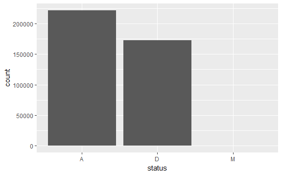

Values distribution of the categorical variable `status`.

```r
ggplot2::ggplot(data = bci12full7) +
  ggplot2::geom_bar(mapping = aes(x = status))
```

The categories `A`, `D` and `M`, of the variable `status` mean *alive*, *dead* and *missing* ([data dictionary](https://goo.gl/wGKEE3)). To confirm this we can:

1. count the the number of unique values of the variables `status`;
2. count the the number of unique values of the variables `DFstatus`;
3. join both counts by the shared variable `n`:

```r
# Compare similar code without and with the pipe
# ?magrittr::`%>%` (Ctrl | Command + shift + M)
status_n <- dplyr::count(bci12full7, status)
DFstatus_n <- bci12full7 %>% dplyr::count(DFstatus)
dplyr::full_join(status_n, DFstatus_n)
```

```
#> # A tibble: 3 x 3
#>   status      n  DFstatus
#>    <chr>  <int>     <chr>
#> 1      A 221758     alive
#> 2      D 172848      dead
#> 3      M     52 no_record
```

### Continuous Variables

> A variable is continuous if it can take any of an infinite set of ordered values.

> To examine the distribution of a continuous variable use a histogram.

> You should always explore a variety of binwidths when working with histograms, as different binwidths can reveal different patterns.

– [R for Data Science](http://r4ds.had.co.nz/).

Let’s use a histogram to explore the variable `dbh`, which represents the stem diameter, usually at breast height (see description of `ViewFullTable` variables at the [data dictionary](https://goo.gl/wGKEE3)). Now we will focus on small trees; big trees will be explored later. And we will try bars of different widths and choose one for further analyses.

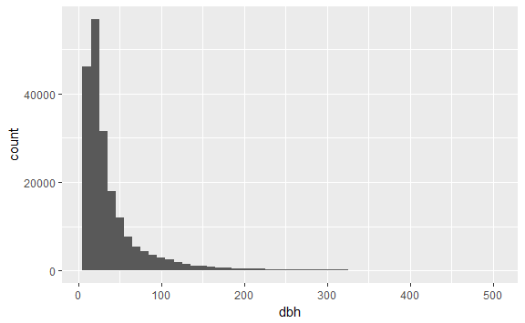

```r
small_dbh <- dplyr::filter(bci12full7, dbh < 500)

# Save data and mappings in "p" to reuse them later.
p <- ggplot(data = small_dbh, mapping = aes(x = dbh))
p + geom_histogram(binwidth = 10)
```

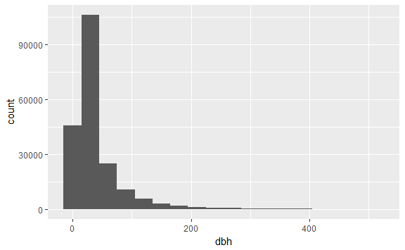

```r
p + geom_histogram(aes(dbh), binwidth = 30)
```

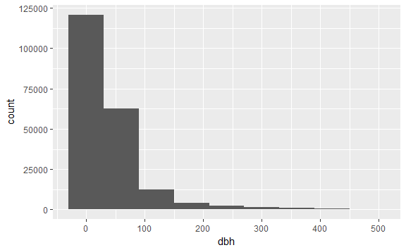

```r
p + geom_histogram(aes(dbh), binwidth = 60)
```

A bar width of 30 `dbh` seems useful.

```r
# Save to reuse
useful_barwidth <- 30
```

The code above uses the temporary variable *p*; this reduces the boilerplate code and helps you focus on important changes. Yet this technique must be used carefully. It is good practice to avoid uninformative temporary names like *p* unless the meaning is obvious from the context and the “life” of the temporary variable is clearly limited to a discrete code chunk. Generally, prefer long informative names over short uninformative ones (http://a.co/4f8df29).

Alternatively, you can reduce the boilerplate code even further and without temporary variables by:

1. writing a custom function with an argument to vary binwidth;
2. using `purrr::map()` (in the tidyverse) or `lapply()` to iteratively pass different binwidths to our custom function:

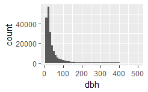

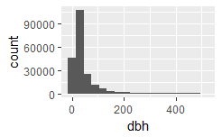

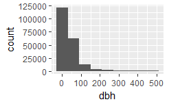

```r
# Use the DRY principle (Don't Repeat Yourself)
ggplot_histogram_by_binwidth <- function(binwidth) {
  ggplot(data = small_dbh, mapping  = aes(x = dbh)) +
    geom_histogram(binwidth = binwidth)
}

binwidths_to_try <- c(10, 30, 60)
purrr::map(.x = binwidths_to_try, .f = ggplot_histogram_by_binwidth)
```

To overlay multiple histograms in the same plot, `geom_freqpoly()` may produce clearer plots than `geom_histogram()` because it is easier to understand overlying lines than bars.

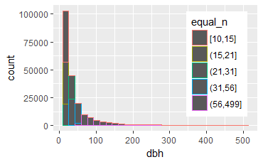

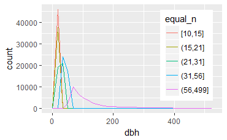

For multiple histograms, lines are easier to understand than bars.

```r
# Make n groups with ~ numbers of observations with `ggplot2::cut_number()`
small_cut_number <- mutate(small_dbh, equal_n = cut_number(dbh, n = 5))

p <- ggplot(data = small_cut_number, aes(x = dbh, color = equal_n)) +
  # use available space on plot area (defult plots legend outside)
  theme(
    legend.position = c(.95, .95),
    legend.justification = c("right", "top")
  )

# Left
p + geom_histogram()
# Right
p + geom_freqpoly()
```

### Typical and rare Values

In both bar charts and histograms, tall and short bars let us explore common and less-common values. For example, we could ask:

> - Which values are the most common? Why?
> - Which values are rare? Why? Does that match your expectations?
> - Can you see any unusual patterns? What might explain them?

– [R for Data Science](http://r4ds.had.co.nz/).

The later two plots give a good estimate of what tree diameters are most common. You can compute the same count manually, by cutting the variable `dbh` with `ggplot2::cut_width()` and then counting the unique pieces with `dplyr::count()`:

```r
small_cut_width <- small_dbh %>%
  dplyr::mutate(dbh_cut = ggplot2::cut_width(dbh, width = useful_barwidth))

small_cut_width %>%
  dplyr::count(dbh_cut, sort = TRUE)
```

```
#> # A tibble: 18 x 2
#>     dbh_cut      n
#>      <fctr>  <int>
#> 1   (15,45] 106249
#> 2  [-15,15]  46024
#> 3   (45,75]  25191
#> 4  (75,105]  10867
#> 5 (105,135]   5998
#> 6 (135,165]   3173
#> # ... with 12 more rows
```

Although the most common trees are those which diameter (`dbh`) is between 15 mm and 45 mm, smaller trees are generally more common than bigger trees, which we already learned from previous plots.

### Clustered values

In this section we will focus on the largest trees; later we will explore all trees, including medium-size ones.

```r
largest_dbh <- bci12full7 %>%
  filter(dbh > 2000)
```

> Clusters of similar values suggest that subgroups exist in your data. To understand the subgroups, ask:
> - How are the observations within each cluster similar to each other?
> - How are the observations in separate clusters different from each other?
> - How can you explain or describe the clusters?
> - Why might the appearance of clusters be misleading?

– [R for Data Science](http://r4ds.had.co.nz/).

The clustering, however, may be an artifact of the chosen bar-width:

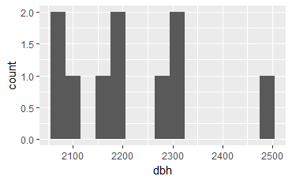

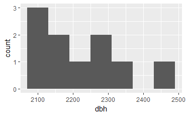

```r
p <- ggplot(largest_dbh, aes(dbh))

# Left: apparent clustering
p + geom_histogram(binwidth = useful_barwidth)

# Right: clusters are less apparent with bars twice as wide
p + geom_histogram(binwidth = useful_barwidth * 2)
```

### Unusual values

(From [R for Data Science](http://r4ds.had.co.nz/), except examples and some text.)

In this section we will work with the entire bci12full7 data set.

Outliers are observations that are unusual; data points that don’t seem to fit the pattern. Sometimes outliers are data entry errors; other times outliers suggest important new science. When you have a lot of data, outliers are sometimes difficult to see in a histogram.

For example, take the distribution of the *dbh* variable of the *bci12full7* data set. The only evidence of outliers is the unusually wide limits on the x-axis (stress mine).

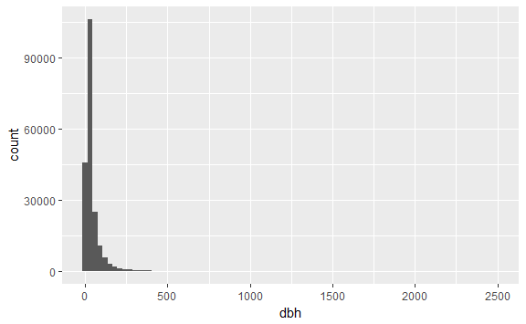

```r
p <- ggplot(bci12full7, aes(x = dbh)) +
  geom_histogram(binwidth = useful_barwidth)
p
```

There are so many observations in the common bins that the rare bins are so short that you can’t see them . To make it easy to see the unusual values, we need to zoom to small values of the y-axis with `coord_cartesian()`:

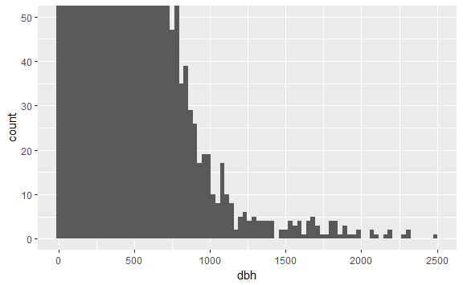

```r
p + coord_cartesian(ylim = c(0, 50))
```

`coord_cartesian()` also has an `xlim()` argument for when you need to zoom into the x-axis. ggplot2 also has `xlim()` and `ylim()` functions that work slightly differently: they throw away the data outside the limits.

This allows us to see that `dbh` values over 2000 are unusual. We pluck them out with `dplyr::filter()` and select a subset of informative variables:

```r
unusual_trees <- bci12full7 %>%
  filter(dbh > 2000) %>%
  dplyr::select(treeID, ExactDate, status, gx, gy, dbh) %>%
  dplyr::arrange(dbh)

unusual_trees
```

```
#> # A tibble: 10 x 6
#>   treeID  ExactDate status    gx    gy   dbh
#>    <int>      <chr>  <chr> <dbl> <dbl> <dbl>
#> 1    897 2011-03-28      A   884 197.7  2080
#> 2   5169 2010-08-07      A   389 166.9  2085
#> 3   3634 2010-08-23      A   577  22.1  2103
#> 4   3608 2010-08-23      A   589  60.3  2172
#> 5   2564 2010-08-30      A   716  27.2  2180
#> 6   1160 2011-03-28      A   861  39.9  2200
#> # ... with 4 more rows
```

You could plot the unusual trees to see where they are located. A number of the unusually large trees seem to be on the edge of the plot, where `gy` values are lower than 100 (left plot below). This information helps us to filter those edge trees selectively (right plot below).

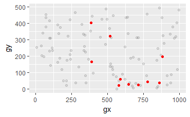

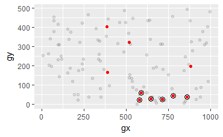

```r
# Left
sample_100 <- bci12full7 %>%
  dplyr::sample_n(100)  # for faster analysis and to avoid overplotting

ggplot(sample_100, aes(gx, gy)) +
    # plot a few points for reference with only 1/10 opacity (less distracting)
    geom_point(alpha = 1/10) +
    # highlight location of unusual trees in the plot
    geom_point(data = unusual_trees, colour = "red")

# Right
edge_trees <- unusual_trees %>%
  filter(gy < 100)

ggplot2::last_plot() +
  geom_point(data = edge_trees, size = 3, shape = 1)  # highlight edge trees
```

Now you can decide what to do with the unusual and edge trees.

It’s good practice to repeat your analysis with and without the outliers. If they have minimal effect on the results, and you can’t figure out why they’re there, it’s reasonable to replace them with missing values, and move on. However, if they have a substantial effect on your results, you shouldn’t drop them without justification. You’ll need to figure out what caused them (e.g. a data entry error) and disclose that you removed them in your write-up.

# Missing Values

(From [R for Data Science](http://r4ds.had.co.nz/), except examples and some text.)

If you’ve encountered unusual values in your data set, and simply want to move on to the rest of your analysis, you have two options.

1. Drop the entire row with the strange values:

   ```r
   are_usual <- !bci12full7$treeID %in% unusual_trees$treeID
   usual_trees <- filter(bci12full7, are_usual)

   # Confirm data set of usual trees has less rows than full data set.
   nrow(bci12full7)
   ```

   ```
   #> [1] 394658
   ```

   ```r
   nrow(usual_trees)
   ```

   ```
   #> [1] 394648
   ```

   I don’t recommend this option because just because one measurement is invalid, doesn’t mean all the measurements are. Additionally, if you have low quality data, by time that you’ve applied this approach to every variable you might find that you don’t have any data left!
2. Instead, I recommend replacing the unusual values with missing values. The easiest way to do this is to use `mutate()` to replace the variable with a modified copy. You can use the `ifelse()` function to replace unusual values with `NA`:

   ```r
   are_unusual <- !are_usual
   with_unusual_made_NA <- bci12full7 %>%
     mutate(dbh = ifelse(are_unusual, NA_real_, dbh))
   ```

`ifelse()` has three arguments. The first argument `test` should be a logical vector. The result will contain the value of the second argument, `yes`, when `test` is `TRUE`, and the value of the third argument, `no`, when it is false.

Alternatively to ifelse, use `dplyr::case_when()`.

> `case_when()` is particularly useful inside mutate when you want to create a new variable that relies on a complex combination of existing variables

–`?dplyr::case_when`

```r
# Confirm no rows have been removed,
nrow(bci12full7)
```

```
#> [1] 394658
```

```r
nrow(with_unusual_made_NA)
```

```
#> [1] 394658
```

```r
# but dbh of unusual trees is NA
unusual_only <- with_unusual_made_NA %>%
  filter(are_unusual) %>%
  select(dbh, treeID)
unusual_only
```

```
#> # A tibble: 10 x 2
#>     dbh treeID
#>   <dbl>  <int>
#> 1    NA    897
#> 2    NA   1160
#> 3    NA   1903
#> 4    NA   2564
#> 5    NA   2935
#> 6    NA   3608
#> # ... with 4 more rows
```

Like R, ggplot2 subscribes to the philosophy that missing values should never silently go missing. It’s not obvious where you should plot missing values, so ggplot2 doesn’t include them in the plot, but it does warn that they’ve been removed (left plot below). To suppress that warning, set `na.rm = TRUE` (right plot below).

```r
# Left: don't remove NAs and get a warning on the console
ggplot(unusual_only, aes(dbh)) +
  geom_histogram(binwidth = useful_barwidth) +
  labs(title = "Expect empty plot but get a warning")
```

```
#> Warning: Removed 10 rows containing non-finite values (stat_bin).
```

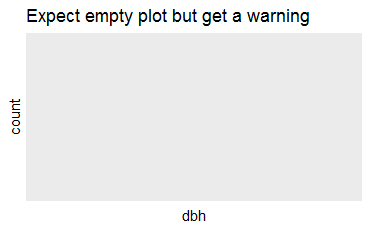

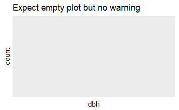

```r
# Right: NAs explicitely removed in geom_histogram(), so no warning
ggplot(unusual_only, aes(dbh)) +
  geom_histogram(binwidth = useful_barwidth, na.rm = TRUE) +
  labs(title = "Expect empty plot but no warning")
```

Other times you want to understand what makes observations with missing values different to observations with recorded values.

For example, in `bci::bci12full7`, some missing values in the `dbh` variable correspond to alive trees. So you might want to compare the `DFstatus` for trees with missing and non-missing values of `dbh`. You can do this by making a new variable with `is.na()`.

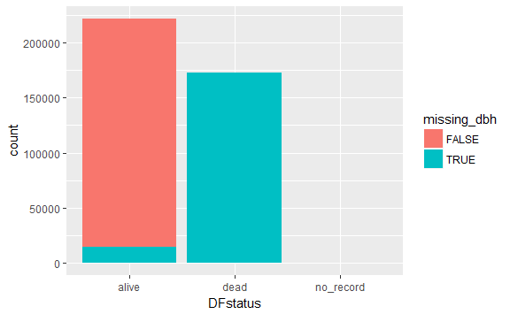

```r
missing_dbh_trees <- bci12full7 %>%
  mutate(missing_dbh = is.na(dbh))

ggplot(missing_dbh_trees) +
  geom_bar(aes(DFstatus, fill = missing_dbh))
```

To know why `dbh` is missing in alive trees, you may want to further explore all variables with a single unique value when `dbh = NA` and `DFstatus = "alive"`:

```r
has_single_unique_value <- function(x) {dplyr::n_distinct(x) == 1}

missing_dbh_trees %>%
  filter(missing_dbh == TRUE, DFstatus == "alive") %>%
  select_if(has_single_unique_value) %>%
  unique()
```

```
#> # A tibble: 1 x 9
#>   CensusID   dbh   pom   hom DFstatus nostems status   agb missing_dbh
#>      <int> <dbl> <chr> <dbl>    <chr>   <dbl>  <chr> <dbl>       <lgl>
#> 1      171    NA  <NA>    NA    alive       1      A     0        TRUE
```

## Exercises

1. What happens to missing values in a histogram? What happens to missing values in a bar chart? Why is there a difference?
2. What does `na.rm = TRUE` do in `mean()` and `sum()`?

# Covariation

(From [R for Data Science](http://r4ds.had.co.nz/), except examples and some text.)

If variation describes the behavior *within* a variable, co-variation describes the behavior *between* variables. **Covariation** is the tendency for the values of two or more variables to vary together in a related way. The best way to spot co-variation is to visualize the relationship between two or more variables. How you do that should again depend on the type of variables involved.

## A categorical and continuous variable

It’s common to want to explore the distribution of a continuous variable broken down by a categorical variable. The default appearance of `geom_freqpoly()` is not that useful for that sort of comparison because the height is given by the count. That means if one of the groups is much smaller than the others, it’s hard to see the differences in shape. For example, let’s explore how stem diameter (`dbh`) varies with species (`sp`):

```
#> Warning: Removed 47617 rows containing non-finite values (stat_bin).
```

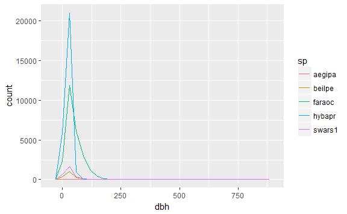

```r
# The data set has too many species; choosing just a few to make this point
a_few_species <- bci12full7 %>%
  select(sp) %>%
  unique() %>%
  pull() %>%
  .[1:5]
data_few_sp <- bci12full7 %>%
  filter(sp %in% a_few_species)

ggplot(data_few_sp, aes(dbh)) +
  geom_freqpoly(aes(color = sp))
```

It’s hard to see the difference in distribution because the overall counts differ so much:

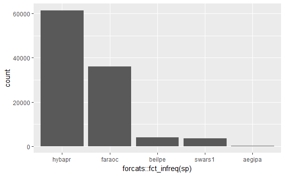

```r
library(forcats)  # tools for dealing with categorical variables

ggplot(data_few_sp) +
  # order `sp` from high to low frequency
  geom_bar(mapping = aes(x = forcats::fct_infreq(sp)))
```

To make the comparison easier we need to swap what is displayed on the y-axis. Instead of displaying count, we’ll display **density**, which is the count standardized so that the area under each frequency polygon is one.

```
#> Warning: Removed 47617 rows containing non-finite values (stat_bin).
```

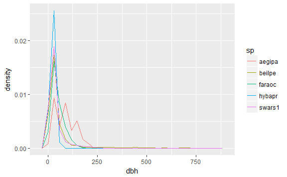

```r
ggplot(data_few_sp, aes(x= dbh, y = ..density..)) +
  geom_freqpoly(aes(color = sp))
```

Another alternative to display the distribution of a continuous variable broken down by a categorical variable is the boxplot. A **boxplot** is a type of visual shorthand for a distribution of values that is popular among statisticians. Each boxplot consists of:

- A box that stretches from the 25th percentile of the distribution to the 75th percentile, a distance known as the interquartile range (IQR). In the middle of the box is a line that displays the median, i.e. 50th percentile, of the distribution. These three lines give you a sense of the spread of the distribution and whether or not the distribution is symmetric about the median or skewed to one side.
- Visual points that display observations that fall more than 1.5 times the IQR from either edge of the box. These outlying points are unusual so are plotted individually.
- A line (or whisker) that extends from each end of the box and goes to the  
  farthest non-outlier point in the distribution.

Let’s take a look at the distribution of tree diameter (`dbh`) by species (`sp`) using `geom_boxplot()`:

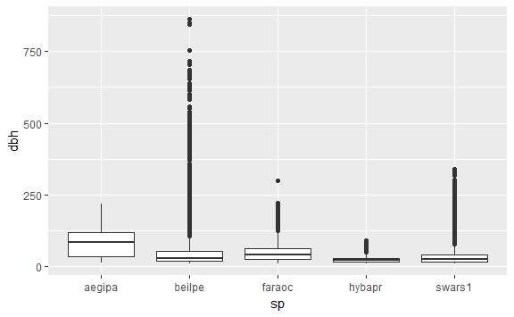

```r
ggplot(data_few_sp, aes(sp, dbh)) +
  geom_boxplot()
```

We see much less information about the distribution, but the boxplots are much more compact so we can more easily compare them (and fit more on one plot).

Above we ordered the variable `sp` by its frequency. But now, to make the trend easier to see, we can reorder `sp` based on the median value of `dbh`. One way to do that is with the `reorder()` function.

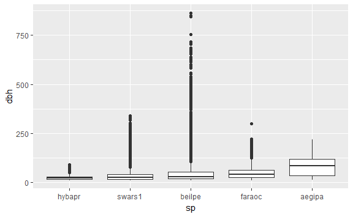

```r
data_few_sp <- data_few_sp %>%
  mutate(sp = reorder(sp, dbh, FUN = median, na.rm = TRUE))

ggplot(data_few_sp, aes(sp, dbh)) +
  geom_boxplot()
```

If you have long variable names, `geom_boxplot()` will work better if you flip it 90°. You can do that with `coord_flip()` (left plot below), or with `ggstance::geom_boxploth()` and swapping `x` and `y` mappings (right plot below):

```r
# install.packages("ggstance")
library(ggstance)
```

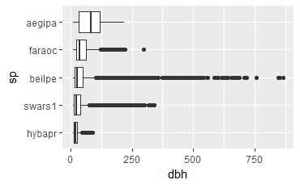

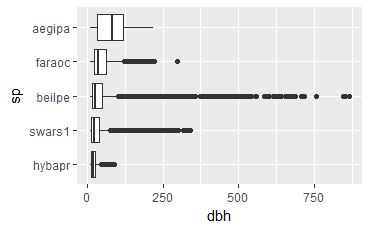

```r
# Left
ggplot2::last_plot() +
  coord_flip()
# Right
ggplot(data_few_sp) +
  ggstance::geom_boxploth(aes(x = dbh, y = sp))  # swap x, y; compare to above
```